# Lab-4-Matrix Decompositions-SVD

```python
import numpy as np
import numpy.linalg as npl
import matplotlib.pyplot as plt
import itertools as it
from matplotlib.pyplot import figure
from sympy import *
from sympy.abc import x
import networkx as nx
from IPython.core.interactiveshell import InteractiveShell
from mpl_toolkits.mplot3d import Axes3D
from matplotlib import cm
import random
from scipy.io import loadmat
import scipy.linalg as spl
import PIL
from PIL import Image
```

```python
InteractiveShell.ast_node_interactivity = "all"
plt.rcParams[ "figure.figsize" ] = (10,10)
origin2D = np.vstack([0,0])
origin3D = np.vstack([0,0,0])
scale = 10
```

## 4.4 Eigendecomposition and Diagonalization

*Intuition behind the eigendecomposition as sequential transformations.*

Some selected notes from this section.

1. A symmetric matrix is a square matrix that is equal to it's transpose.
2. A diagonal matrix is a matrix with zeroes in all off diagonal positions.
3. A matrix '$A$' can be decomposed into $P$ and $D$, $D$ is a diagonal matrix that is $= P^{-1}AP$; and P is invertible.
4. 'A' is a linear mapping. We are looking for another way of expressing the same linear mapping, but in another basis.
5. If there exists an invertible matrix $P$, s.t. $D=P^{-1}AP$, we can say that '$A$' is 'diagonalizable.
6. If a matrix is symmetric, we can say $D = PAP^{-1}$.
7. In SymPy, `Matrix(A).is_diagonalizable()`.
8. In numpy, `eigh` is strictly for symmetric matrices.

## 4.5 Singular Value Decomposition

1. $A$ = $U\Sigma V$.
2. $A$ is $m\times n$.
3. $U$ is $m\times m$.
4. $\Sigma$ is $m\times n$.
5. $V$ is $n\times n$.
6. $\Sigma$ has diagonal entries which are called the 'singular values', these are ordered from greatest to least, top left to bottom right.
7. If $m>n$, up to n are the singular values, the rows after n are padded with zeros, and vice versa if $m<n$.
8. This can be applied to any matrix.

## 4.5.2 Construction of the SVD

1. The SVD of symmetric positive definite, or SPD, matrices is their eigendecomposition..
2. Computing the SVD of an $m\times n$ is equivalent to finding orthonormal bases for U in $m\times m$, and V in $n\times n$.
3. A symmetric matrix possesses an orthonormal basis of eigenvectors, meaning it can be diagonalized.
4. Given any rectangular matrix, we can always construct a symmetric, positive, semidefinite matrix $A^TA$. So $A^TA = PDP^T$. Here P is orthogonal, and composed of an orthonormal eigenbasis.
5. The SVD requires computing the right singular vectors $v_j$, singular values $\sigma_k$, and left singular vectors $u_i$.

```python
A = np.vstack([[1,0,1],[-2,1,0]])
Matrix(A)
```

$\displaystyle \left[\begin{matrix}1 & 0 & 1\\-2 & 1 & 0\end{matrix}\right]$

```python
ATA = A.T @ A
Matrix(ATA)
```

$\displaystyle \left[\begin{matrix}5 & -2 & 1\\-2 & 1 & 0\\1 & 0 & 1\end{matrix}\right]$

```python
vals, vecs = npl.eig(ATA)
D = np.eye(3) * np.sort(vals)[::-1] # Reordering because numpy eig does not necessarily order.
Matrix(D)
P = np.hstack([np.vstack(vecs[:,0]),np.vstack(vecs[:,2]),np.vstack(vecs[:,1])]) # Reordering because numpy eig does not necessarily order.
Matrix(P)
V = P.copy()
```

$\displaystyle \left[\begin{matrix}6.0 & 0 & 0\\0 & 1.0 & 0\\0 & 0 & -4.44089209850063 \cdot 10^{-16}\end{matrix}\right]$

$\displaystyle \left[\begin{matrix}0.912870929175277 & 0 & -0.408248290463863\\-0.365148371670111 & 0.447213595499958 & -0.816496580927726\\0.182574185835055 & 0.894427190999916 & 0.408248290463863\end{matrix}\right]$

```python
# sqrt of D, with padded 0's to match shape of A
S = np.hstack([np.sqrt(D)[0:npl.matrix_rank(A),:npl.matrix_rank(A)],np.vstack([0,0])])
Matrix(S)
```

$\displaystyle \left[\begin{matrix}2.44948974278318 & 0 & 0\\0 & 1.0 & 0\end{matrix}\right]$

```python
sigmas = np.sqrt(np.sort(vals)[::-1][:2])
vs = [np.vstack(V[:,0]),np.vstack(V[:,1])]
sigmas
vs
```

```
array([2.44948974, 1.        ])
```

```
[array([[ 0.91287093],
        [-0.36514837],
        [ 0.18257419]]),
 array([[0.        ],
        [0.4472136 ],
        [0.89442719]])]
```

```python
U = np.hstack([(1/i)*A@vs[ind] for ind,i in enumerate(sigmas)])
Matrix(U)
```

$\displaystyle \left[\begin{matrix}0.447213595499958 & 0.894427190999916\\-0.894427190999916 & 0.447213595499958\end{matrix}\right]$

```python
Matrix(A)
Matrix(U@S@V.T)
```

$\displaystyle \left[\begin{matrix}1 & 0 & 1\\-2 & 1 & 0\end{matrix}\right]$

$\displaystyle \left[\begin{matrix}1.0 & 0 & 1.0\\-2.0 & 1.0 & -5.55111512312578 \cdot 10^{-17}\end{matrix}\right]$

A note on the differences between the book example and the numpy implemention, `npl.svd`.

1. While `npl.eig` does not order, `npl.svd` does order.
2. S in numpy SVD is not reshaped or padded.
3. V in numpy SVD is already transposed.

```python
numU,numS,numV = npl.svd(A)
Matrix(numU)
Matrix(U)
Matrix(numS)
Matrix(S)
Matrix(numV)
Matrix(V)
```

$\displaystyle \left[\begin{matrix}0.447213595499958 & 0.894427190999916\\-0.894427190999916 & 0.447213595499958\end{matrix}\right]$

$\displaystyle \left[\begin{matrix}0.447213595499958 & 0.894427190999916\\-0.894427190999916 & 0.447213595499958\end{matrix}\right]$

$\displaystyle \left[\begin{matrix}2.44948974278318\\1.0\end{matrix}\right]$

$\displaystyle \left[\begin{matrix}2.44948974278318 & 0 & 0\\0 & 1.0 & 0\end{matrix}\right]$

$\displaystyle \left[\begin{matrix}0.912870929175277 & -0.365148371670111 & 0.182574185835055\\-4.44089209850063 \cdot 10^{-16} & 0.447213595499958 & 0.894427190999916\\-0.408248290463863 & -0.816496580927726 & 0.408248290463863\end{matrix}\right]$

$\displaystyle \left[\begin{matrix}0.912870929175277 & 0 & -0.408248290463863\\-0.365148371670111 & 0.447213595499958 & -0.816496580927726\\0.182574185835055 & 0.894427190999916 & 0.408248290463863\end{matrix}\right]$

```python
Matrix(A)
Matrix(U@S@V.T)
Matrix(numU@np.hstack([np.eye(2)*numS,np.vstack([0,0])])@numV)
```

$\displaystyle \left[\begin{matrix}1 & 0 & 1\\-2 & 1 & 0\end{matrix}\right]$

$\displaystyle \left[\begin{matrix}1.0 & 0 & 1.0\\-2.0 & 1.0 & -5.55111512312578 \cdot 10^{-17}\end{matrix}\right]$

$\displaystyle \left[\begin{matrix}1.0 & 5.55111512312578 \cdot 10^{-17} & 1.0\\-2.0 & 1.0 & 2.77555756156289 \cdot 10^{-16}\end{matrix}\right]$

# #

```python
A = np.vstack([[1,-.8],[0,1],[1,0]])
Matrix(A)
U = np.vstack([[-.79,0,-.62],[.38,-.78,-.49],[-.48,-.62,.62]])
S = np.vstack([[1.62,0],[0,1.0],[0,0]])
V = np.vstack([[-.78,-.62],[.62,-.78]])
Matrix(U)
Matrix(S)
Matrix(V.T)
```

$\displaystyle \left[\begin{matrix}1.0 & -0.8\\0 & 1.0\\1.0 & 0\end{matrix}\right]$

$\displaystyle \left[\begin{matrix}-0.79 & 0 & -0.62\\0.38 & -0.78 & -0.49\\-0.48 & -0.62 & 0.62\end{matrix}\right]$

$\displaystyle \left[\begin{matrix}1.62 & 0\\0 & 1.0\\0 & 0\end{matrix}\right]$

$\displaystyle \left[\begin{matrix}-0.78 & 0.62\\-0.62 & -0.78\end{matrix}\right]$

Steps:

1. $V_{cols}$ = eigenvectors(ATA), check for ordering
2. $U_{cols}$ = eigenvectors(AAT), check for ordering
3. $S_{i,i}$ = sqrt(sort(eigenalues(AAT or ATA) if $\neq 0$))))

```python
npl.eig(A@A.T)
npl.eig(A.T@A)
```

```
(array([ 2.64000000e+00, -2.22044605e-16,  1.00000000e+00]),
 array([[ 0.78817011, -0.61545745,  0.        ],
        [-0.38447322, -0.49236596,  0.78086881],
        [ 0.48059153,  0.61545745,  0.62469505]]))
```

```
(array([2.64, 1.  ]),
 array([[ 0.78086881,  0.62469505],
        [-0.62469505,  0.78086881]]))
```

```python
numU = npl.eig(A@A.T)[1]
numU = np.hstack([np.vstack(numU[:,0]),np.vstack(numU[:,2]),np.vstack(numU[:,1])])
numS = np.vstack([np.eye(2)*[i for i in np.sqrt(np.sort(npl.eig(A.T@A)[0])[::-1]) if np.isnan(i) == False],[0,0]])
numV = npl.eig(A.T@A)[1]
numU
numS
numV.T
```

```
array([[ 0.78817011,  0.        , -0.61545745],
       [-0.38447322,  0.78086881, -0.49236596],
       [ 0.48059153,  0.62469505,  0.61545745]])
```

```
array([[1.62480768, 0.        ],
       [0.        , 1.        ],
       [0.        , 0.        ]])
```

```
array([[ 0.78086881, -0.62469505],
       [ 0.62469505,  0.78086881]])
```

We can check the $U\Sigma V^{T}$ result.

```python
A
numU@numS@numV.T
```

```
array([[ 1. , -0.8],
       [ 0. ,  1. ],
       [ 1. ,  0. ]])
```

```
array([[ 1.00000000e+00, -8.00000000e-01],
       [-1.11022302e-16,  1.00000000e+00],
       [ 1.00000000e+00,  0.00000000e+00]])
```

We can again compare with `npl.svd`, to find the same idiosyncracies noted above.

1. While `npl.eig` does not order, `npl.svd` does order.
2. S in numpy SVD is not reshaped or padded.
3. V in numpy SVD is already transposed.

```python
npl.svd(A)
```

```
(array([[-7.88170109e-01,  1.66533454e-16, -6.15457455e-01],
        [ 3.84473224e-01, -7.80868809e-01, -4.92365964e-01],
        [-4.80591530e-01, -6.24695048e-01,  6.15457455e-01]]),
 array([1.62480768, 1.        ]),
 array([[-0.78086881,  0.62469505],
        [-0.62469505, -0.78086881]]))
```

## 4.5.3 Eigenvalue Decomposition vs Singular Value Decomposition

Similarities:

1. Change of basis in the domain.
2. Independent scaling of each new basis from domain to codomain.
3. Change of basis in the codomain.

Differences:

1. Generally U and V are not inverses of each other.
2. S is generally real, whereas entries in D are not usually.

### Example 4.14 (Finding Structure in Movie Ratings and Consumers)

#### Figure 4.10

*Movie ratings by three people for four movies and its SVD decomposition*.

```python
A = np.vstack([[5,4,1],[5,5,0],[0,0,5],[1,0,4]])
Matrix(A)
```

$\displaystyle \left[\begin{matrix}5 & 4 & 1\\5 & 5 & 0\\0 & 0 & 5\\1 & 0 & 4\end{matrix}\right]$

```python
U,S,V = npl.svd(A)
S = np.vstack([np.eye(3)*S.copy(),[0,0,0]])
U
S
V
U@S@V
```

```
array([[-0.67096878,  0.02362898,  0.46466034, -0.57735027],
       [-0.7197425 ,  0.20541998, -0.47585716,  0.46188022],
       [-0.09389374, -0.77048084, -0.52682373, -0.34641016],
       [-0.15151103, -0.6029955 ,  0.52925183,  0.57735027]])
```

```
array([[9.6438109 , 0.        , 0.        ],
       [0.        , 6.36389089, 0.        ],
       [0.        , 0.        , 0.70555232],
       [0.        , 0.        , 0.        ]])
```

```
array([[-0.73674894, -0.65146317, -0.1810987 ],
       [ 0.0852072 ,  0.17624687, -0.9806512 ],
       [ 0.67077622, -0.73792464, -0.07434034]])
```

```
array([[ 5.00000000e+00,  4.00000000e+00,  1.00000000e+00],
       [ 5.00000000e+00,  5.00000000e+00,  5.27355937e-16],
       [ 2.77555756e-16, -1.66533454e-16,  5.00000000e+00],
       [ 1.00000000e+00,  1.11022302e-16,  4.00000000e+00]])
```

*Note: Implementing this a layer of abstraction below `npl.svd` with `npl.eig` is tricky because eigenvectors are calculated with a 4th, negative 0 eigenvalue. This is an instance where, `npl.svd` is safer to use.*

The decomposition can be interpreted in terms of large absolute values. $U_1$ has large absolute values for two science fiction movies, and it's corresponding singular value in $S_1$ is also large. This indicates a grouping of movies, and of people. Also, $V_1$ has large absolute values, indicating a grouping among people.

An SVD of a set of movies and a set of people can be decomposed and represented as groups using SVD.

Full SVD:

1. $A$ = $U\Sigma V$.
2. $A$ is $m\times n$.
3. $U$ is $m\times m$.
4. $\Sigma$ is $m\times n$.
5. $V$ is $n\times n$.

Reduced SVD:

1. $A$ = $U\Sigma V$.
2. $A$ is $m\times n$.
3. $U$ is $m\times n$.
4. $\Sigma$ is $n\times n$.
5. $V$ is $n\times n$.

## 4.6 Matrix Approximation

Matrices can be approximated as lower-quality versions of themselves using SVD. By taking the sum of some amount of columns in U, that same amount of rows in V, and scaling them by that same amount of singular values in S, you can get increasingly accurate approximations of S. This takes advantage of the value of singular values decreasing.

First we start by importing an image, converting it to greyscale, and converting that to a `numpy` array.

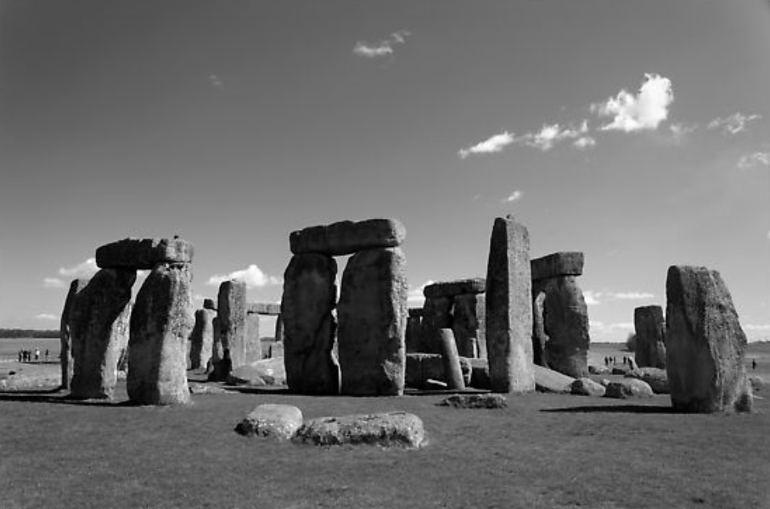

```
'PNG'
```

```
(960, 635)
```

```
'RGBA'
```

```python
stonehenge = Image.open('qtluong.png')
stonehenge
stonehenge.format
stonehenge.size
stonehenge.mode
```

```python
gsMatrix = np.array(stonehenge.convert("L"))/255 # Conversion to a greyscale, numpy array, with values 0-1.
np.shape(gsMatrix)
gsMatrix
```

```
(635, 960)
```

```
array([[0.35294118, 0.34509804, 0.3372549 , ..., 0.48627451, 0.46666667,
        0.48627451],
       [0.32156863, 0.32941176, 0.31372549, ..., 0.47843137, 0.45098039,
        0.4627451 ],
       [0.34117647, 0.37647059, 0.34117647, ..., 0.49019608, 0.47058824,
        0.47058824],
       ...,
       [0.41568627, 0.41568627, 0.41960784, ..., 0.39215686, 0.39215686,
        0.4       ],
       [0.42352941, 0.43137255, 0.42745098, ..., 0.38431373, 0.39607843,
        0.4       ],
       [0.43137255, 0.45098039, 0.42745098, ..., 0.37254902, 0.39607843,
        0.39607843]])
```

```
((635, 635), (635, 960), (960, 960))
```

```
True
```

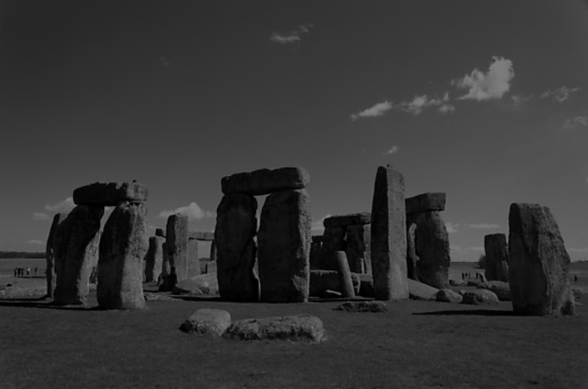

```python
scalar = 1/2 # Testing reconstruction of image.
shape = np.shape(gsMatrix)
U,S,V = npl.svd(gsMatrix)
Sd = np.hstack([np.eye(shape[0])*S.copy(),np.zeros((shape[0],shape[1]-shape[0]))])
np.shape(U),np.shape(Sd),np.shape(V)
np.allclose(gsMatrix,U@Sd@V)
Image.fromarray((U@Sd@V*255*scalar).astype('uint8'))
```

#### Figure 4.11

Every step of summation for approximating a matrix is decreasingly rich in information about the original matrix trying to be approximated. The image created by each step of summation is gridlike because of the outer-product being taken between the left and right-singular vectors, $u_i, v_i$.

```
(635, 1)
```

```
(1, 1)
```

```
(1, 960)
```

```
(2, [(635, 960), (635, 635), (635, 960), (960, 960)])
```

```
(1596, 609600, 0.0026181102362204723)
```

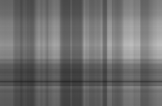

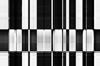

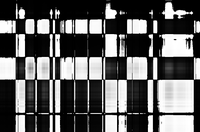

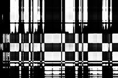

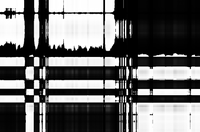

```python
k = 1
np.shape(U[:,:k])
np.shape(np.diag(S[:k]))
np.shape(V.T[:,:k].T)
m,n = np.shape(gsMatrix)
partial,total = k*(m+n)+k, m*n
np.ndim(gsMatrix),[np.shape(i) for i in [gsMatrix,U,Sd,V]]
partial,total, partial/total

size = (200,200)
imtemp = lambda k: (np.vstack(U[:,k-1])@np.vstack([S[k-1]])@np.vstack(V[k-1]).T)*255
for i in list(range(1,6)):
    im = Image.fromarray(imtemp(i).astype('uint8'))
    im.thumbnail(size, Image.ANTIALIAS)
    im
```

#### Figure 4.12

Reconstruction of the original is shown using low-rank approximation of the SVD, where the rank-k approximation is given by the sum of the scaled outer product between u and v.

```
(5, 5)
```

```
(635, 5)
```

```
(5, 960)
```

```
(2, [(635, 960), (635, 635), (635, 960), (960, 960)])
```

```
(7980, 609600, 0.013090551181102363)
```

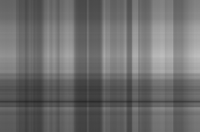

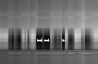

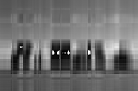

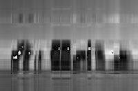

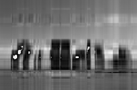

```python
quality = 5
np.shape(np.diag(S[:quality]))
np.shape(U[:,:quality])
np.shape(V[:quality,:])
k = quality
m,n = np.shape(gsMatrix)
partial,total = k*(m+n)+k, m*n
np.ndim(gsMatrix),[np.shape(i) for i in [gsMatrix,U,Sd,V]]
partial,total, partial/total

imtemp = lambda k: (U[:,:k]@np.diag(S[:k])@V.T[:,:k].T)*255 # V[:k,:] also works
for i in list(range(1,k+1)):
    im = Image.fromarray(imtemp(i).astype('uint8'))
    im.thumbnail(size, Image.ANTIALIAS)
    im
```

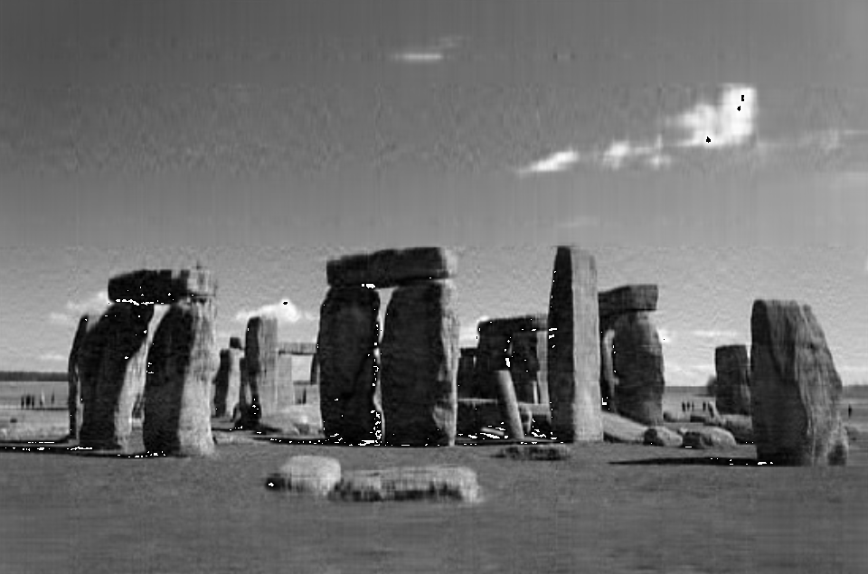

```
(79800, 609600, 0.1309055118110236)
```

```python
k = 50
Image.fromarray(imtemp(k).astype('uint8')) # An approximation at rank 50.
m,n = np.shape(gsMatrix)
partial,total = (k*(m+n)+k, m*n)
partial,total, partial/total
```

Note the calculations that were added along the way for data storage proportion. The approximation at rank 50, above, is $13.09\%$ of the original. Also note that at some point the storage exceeds the original, which is a reminder that this is expressly meant for low-rank approximation.

We can also measure how much error exists between the approximation and the original.

```python
A = gsMatrix
k = 5
aHat = imtemp(k)/255
A
aHat
npl.norm(A)
S[0]
npl.norm(A-aHat)
S[k+1] # The Eckart-Young theorem not holding here 100%, will have to debug later.
```

```
array([[0.35294118, 0.34509804, 0.3372549 , ..., 0.48627451, 0.46666667,
        0.48627451],
       [0.32156863, 0.32941176, 0.31372549, ..., 0.47843137, 0.45098039,
        0.4627451 ],
       [0.34117647, 0.37647059, 0.34117647, ..., 0.49019608, 0.47058824,
        0.47058824],
       ...,
       [0.41568627, 0.41568627, 0.41960784, ..., 0.39215686, 0.39215686,
        0.4       ],
       [0.42352941, 0.43137255, 0.42745098, ..., 0.38431373, 0.39607843,
        0.4       ],
       [0.43137255, 0.45098039, 0.42745098, ..., 0.37254902, 0.39607843,
        0.39607843]])
```

```
array([[0.32632101, 0.32866196, 0.32678015, ..., 0.4785917 , 0.47714393,
        0.47964494],
       [0.3274938 , 0.32978068, 0.32787427, ..., 0.47832083, 0.47690242,
        0.47931358],
       [0.32701555, 0.32934538, 0.32745455, ..., 0.47894579, 0.47749787,
        0.47997791],
       ...,
       [0.34377147, 0.34391171, 0.34171506, ..., 0.3876273 , 0.38700568,
        0.38743425],
       [0.34709101, 0.34725176, 0.34506138, ..., 0.39483198, 0.39418907,
        0.39451986],
       [0.34891987, 0.34914659, 0.34698399, ..., 0.40069038, 0.39999095,
        0.40033005]])
```

```
362.45984232882637
```

```
343.98082419882746
```

```
63.70268172734166
```

```
20.729271947024568
```

### Example 4.15 (Finding Structure in Movie Ratings and Consumers (continued))

```python
# Recall move rating data:
A = np.vstack([[5,4,1],[5,5,0],[0,0,5],[1,0,4]])
Matrix(A)
```

$\displaystyle \left[\begin{matrix}5 & 4 & 1\\5 & 5 & 0\\0 & 0 & 5\\1 & 0 & 4\end{matrix}\right]$

```python
U,S,V = npl.svd(A)
Matrix(U)
Matrix(S)
Matrix(V)
```

$\displaystyle \left[\begin{matrix}-0.670968784133559 & 0.0236289846199741 & 0.464660336666289 & -0.577350269189626\\-0.719742497550142 & 0.205419981431847 & -0.475857158310654 & 0.4618802153517\\-0.0938937434833602 & -0.770480839571349 & -0.526823728383706 & -0.346410161513776\\-0.151511032183462 & -0.602995504268313 & 0.529251826284587 & 0.577350269189626\end{matrix}\right]$

$\displaystyle \left[\begin{matrix}9.64381090011831\\6.36389088878754\\0.705552321494398\end{matrix}\right]$

$\displaystyle \left[\begin{matrix}-0.736748938172854 & -0.651463170457632 & -0.181098701371548\\0.0852072003538232 & 0.176246869287984 & -0.980651198986697\\0.670776218353807 & -0.737924642902969 & -0.0743403409158916\end{matrix}\right]$

```python
k = 1
A1 = np.dot(np.vstack(U[:,k-1]),np.array([V[k-1]]))
np.shape(V[k-1]), np.shape(np.array([V[k-1]])) # Note this trick, also used above, to turn the V column into shape (1,3), rather than (3,).
Matrix(A1)
```

```
((3,), (1, 3))
```

$\displaystyle \left[\begin{matrix}0.494335539257531 & 0.437111451389751 & 0.121511575467434\\0.530269520827945 & 0.46888572936711 & 0.130344431628245\\0.06917611581244 & 0.0611683158158055 & 0.0170040350117498\\0.111625592082639 & 0.0987038573855465 & 0.0274384511718878\end{matrix}\right]$

The significant values, $>.4$, show a grouping of movies, and of people. But no other groupings.

```python
k = 2
A2 = np.dot(np.vstack(U[:,k-1]),np.array([V[k-1]]))
np.shape(V[k-1]), np.shape(np.array([V[k-1]])) # Note this trick, also used above, to turn the V column into shape (1,3), rather than (3,).
Matrix(A2)
```

```
((3,), (1, 3))
```

$\displaystyle \left[\begin{matrix}0.00201335962667154 & 0.00416453456372436 & -0.0231717920984158\\0.017503261514542 & 0.0362046286165587 & -0.201445351086965\\-0.0656505152661379 & -0.135794835820828 & 0.755572959121921\\-0.0513795587446448 & -0.106276069822019 & 0.591328264244309\end{matrix}\right]$

The significant values here, show us data not found in the first. So, it is useful to combine and create $\hat{A}(2)$.

```python
S[0]*A1+S[1]*A2
A
```

```
array([[ 4.78009126,  4.24192282,  1.0243719 ],
       [ 5.22520783,  4.75224761, -0.02495918],
       [ 0.24932866, -0.27428785,  4.97236757],
       [ 0.7495222 ,  0.27555202,  4.02775979]])
```

```
array([[5, 4, 1],
       [5, 5, 0],
       [0, 0, 5],
       [1, 0, 4]])
```

```python
npl.norm(S[0]*A1+S[1]*A2-A)
S[2] # Eckart-Young worked here! :D Maybe a matter of significant values.
```

```
0.7055523214943982
```

```
0.7055523214943978
```